# Lab 3: Exploring Happiness

Due: Thursday 10/03/2019 by 10 pm

Ashley Anderson & Hexiang Zhang

09/26/2019

Owners Username: ashleyna7 Partners Username: hexzha Owners Repo Name: ds202_lab3

## Background

The General Social Survey (GSS) has been run by NORC every other year since 1972 to keep track of current opinions across the United States. We are working with an excerpt of the dataset that covers years 1972 to 2016. The variable names along with a brief description are as follows:

| Variable | Description |
| --- | --- |
| Year | Year for this respondent |
| Age | Age of respondent |
| Sex | Sex of respondent |
| …. | ….. |

Now it’s important to understand what each column stands for. You can find a codebook with explanations for each of the variables at https://gssdataexplorer.norc.org/

```r
library(classdata)
library(dplyr)
happy <- readRDS("HAPPY.rds")
names(happy) = tolower(names(happy))
```

## Data Cleaning

Initial exploration revealed that some data processing was needed before we could proceed with further visualization. The first table below shows the number of missing values for all variables before data cleaning, labeled as “IAP”, “DK”, and “NA”. After this discovery, we changed all missing values labeled as “DK” and “IAP” and relabeled them as “NA”. The second table belows shows this was successful.

```r
na.table <- data.frame()
for(i in 1:ncol(happy)){
  na.table[1,i] <- sum(is.na(happy[i]))
  na.table[2,i] <- length(grep("IAP", happy[,i]))
  na.table[3,i] <- length(grep("DK", happy[,i]))
}
names(na.table) <- colnames(happy)
rownames(na.table) <- c("NAs","IAP","DK")
na.table
```

```
##     happy year age sex marital degree finrela health wtssall partyid
## NAs  4756    0 220   0      25    143     150     90       0     374
## IAP     0    0   0   0       0      0    4383  16325       0       0
## DK      0    0   1   0       0     30     468     30       0      11
##     polviews
## NAs      361
## IAP     6777
## DK      2247
```

```r
happy2 <- happy

na_codes <- c("IAP", "DK", "")
for (i in seq_along(happy2)) {
  happy2[[i]][happy2[[i]] %in% na_codes] <- NA
}

na.table2 <- data.frame()
for(i in 1:ncol(happy2)){
  na.table2[1,i] <- sum(is.na(happy2[i]))
  na.table2[2,i] <- length(grep("IAP", happy2[,i]))
  na.table2[3,i] <- length(grep("DK", happy2[,i]))
}
names(na.table2) <- colnames(happy2)
rownames(na.table2) <- c("NAs","IAP","DK")
na.table2
```

```
##     happy year age sex marital degree finrela health wtssall partyid
## NAs  4756    0 221   0      25    173    5001  16445       0     385
## IAP     0    0   0   0       0      0       0      0       0       0
## DK      0    0   0   0       0      0       0      0       0       0
##     polviews
## NAs     9385
## IAP        0
## DK         0
```

As we can see below, a lot of variables were also cast into the wrong variable type. Age appears to be a character variable, and should be numeric. All categorical variables needed to be changed to type factor (except partyid and polyviews). There were 335 instances where age appeared as “89 OR OLDER”. We changed this for all instances that were labeled as “89 OR OLDER” and labeled them as 89 so the variable age could be changed to type numeric. We can now see below that all variabels are now cast into the correct variable type.

```r
str(happy)
```

```
## 'data.frame':    62466 obs. of  11 variables:
##  $ happy   : chr  "NOT TOO HAPPY" "NOT TOO HAPPY" "PRETTY HAPPY" "NOT TOO HAPPY" ...
##  $ year    : int  1972 1972 1972 1972 1972 1972 1972 1972 1972 1972 ...
##  $ age     : chr  "23" "70" "48" "27" ...
##  $ sex     : chr  "FEMALE" "MALE" "FEMALE" "FEMALE" ...
##  $ marital : chr  "NEVER MARRIED" "MARRIED" "MARRIED" "MARRIED" ...
##  $ degree  : chr  "BACHELOR" "LT HIGH SCHOOL" "HIGH SCHOOL" "BACHELOR" ...
##  $ finrela : chr  "AVERAGE" "ABOVE AVERAGE" "AVERAGE" "AVERAGE" ...
##  $ health  : chr  "GOOD" "FAIR" "EXCELLENT" "GOOD" ...
##  $ wtssall : num  0.445 0.889 0.889 0.889 0.889 ...
##  $ partyid : chr  "IND,NEAR DEM" "NOT STR DEMOCRAT" "INDEPENDENT" "NOT STR DEMOCRAT" ...
##  $ polviews: chr  "IAP" "IAP" "IAP" "IAP" ...
```

```r
length(grep("89 OR OLDER", happy2$age))
```

```
## [1] 335
```

```r
for (i in 1:nrow(happy2)) {
  age <- happy2[i, 'age']
  if(!is.na(age)){
    if(age=="89 OR OLDER") {
      happy2[i, 'age'] <- 89
    }
  }
}

happy2$happy <- as.factor(happy2$happy)
happy2$age <- as.numeric(happy2$age)
happy2$sex <- as.factor(happy2$sex)
happy2$marital <- as.factor(happy2$marital)
happy2$degree <- as.factor(happy2$degree)
happy2$finrela <- as.factor(happy2$finrela)
happy2$health <- as.factor(happy2$health)

str(happy2)
```

```
## 'data.frame':    62466 obs. of  11 variables:
##  $ happy   : Factor w/ 3 levels "NOT TOO HAPPY",..: 1 1 2 1 2 2 1 1 2 2 ...
##  $ year    : int  1972 1972 1972 1972 1972 1972 1972 1972 1972 1972 ...
##  $ age     : num  23 70 48 27 61 26 28 27 21 30 ...
##  $ sex     : Factor w/ 2 levels "FEMALE","MALE": 1 2 1 1 1 2 2 2 1 1 ...
##  $ marital : Factor w/ 5 levels "DIVORCED","MARRIED",..: 3 2 2 2 2 3 1 3 3 2 ...
##  $ degree  : Factor w/ 5 levels "BACHELOR","GRADUATE",..: 1 5 3 1 3 3 3 1 3 3 ...
##  $ finrela : Factor w/ 5 levels "ABOVE AVERAGE",..: 2 1 2 2 1 1 1 2 2 3 ...
##  $ health  : Factor w/ 4 levels "EXCELLENT","FAIR",..: 3 2 1 3 3 3 1 3 1 2 ...
##  $ wtssall : num  0.445 0.889 0.889 0.889 0.889 ...
##  $ partyid : chr  "IND,NEAR DEM" "NOT STR DEMOCRAT" "INDEPENDENT" "NOT STR DEMOCRAT" ...
##  $ polviews: chr  NA NA NA NA ...
```

Factors were also organized into meaningful order as follows: We ordered marital status by age and health by age.

```r
marital.df <- as.data.frame(aggregate(happy2$age, by=list(happy2$marital), mean, na.rm=TRUE))
marital.order <- c(order(marital.df[,"x"]))
happy2$marital <- factor(happy2$marital,levels(happy2$marital)[marital.order])

health.df <- as.data.frame(aggregate(happy2$age, by=list(happy2$health), mean, na.rm=TRUE))
health.order <- c(order(health.df[,"x"]))
happy2$health <- factor(happy2$health,levels(happy2$health)[health.order])

str(happy2)
```

```
## 'data.frame':    62466 obs. of  11 variables:
##  $ happy   : Factor w/ 3 levels "NOT TOO HAPPY",..: 1 1 2 1 2 2 1 1 2 2 ...
##  $ year    : int  1972 1972 1972 1972 1972 1972 1972 1972 1972 1972 ...
##  $ age     : num  23 70 48 27 61 26 28 27 21 30 ...
##  $ sex     : Factor w/ 2 levels "FEMALE","MALE": 1 2 1 1 1 2 2 2 1 1 ...
##  $ marital : Factor w/ 5 levels "NEVER MARRIED",..: 1 3 3 3 3 1 4 1 1 3 ...
##  $ degree  : Factor w/ 5 levels "BACHELOR","GRADUATE",..: 1 5 3 1 3 3 3 1 3 3 ...
##  $ finrela : Factor w/ 5 levels "ABOVE AVERAGE",..: 2 1 2 2 1 1 1 2 2 3 ...
##  $ health  : Factor w/ 4 levels "EXCELLENT","GOOD",..: 2 3 1 2 2 2 1 2 1 3 ...
##  $ wtssall : num  0.445 0.889 0.889 0.889 0.889 ...
##  $ partyid : chr  "IND,NEAR DEM" "NOT STR DEMOCRAT" "INDEPENDENT" "NOT STR DEMOCRAT" ...
##  $ polviews: chr  NA NA NA NA ...
```

## Data Exploration

Two variables of interest are age and happy. Their distributions are as follow:

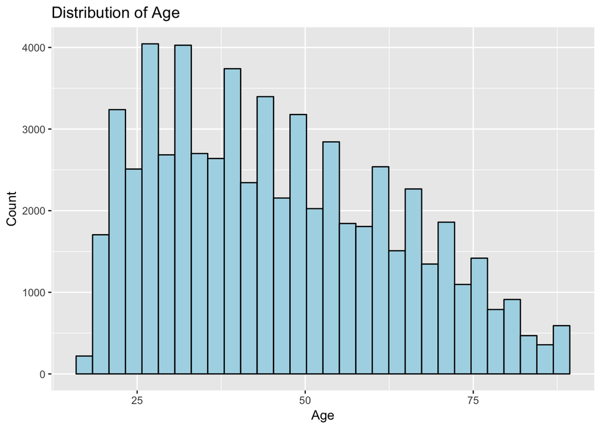

```r
library(ggplot2)
ggplot(happy2, aes(age)) + geom_histogram(color="black", fill="lightblue", size=0.5) + xlab("Age") + ylab("Count") + ggtitle("Distribution of Age")
```

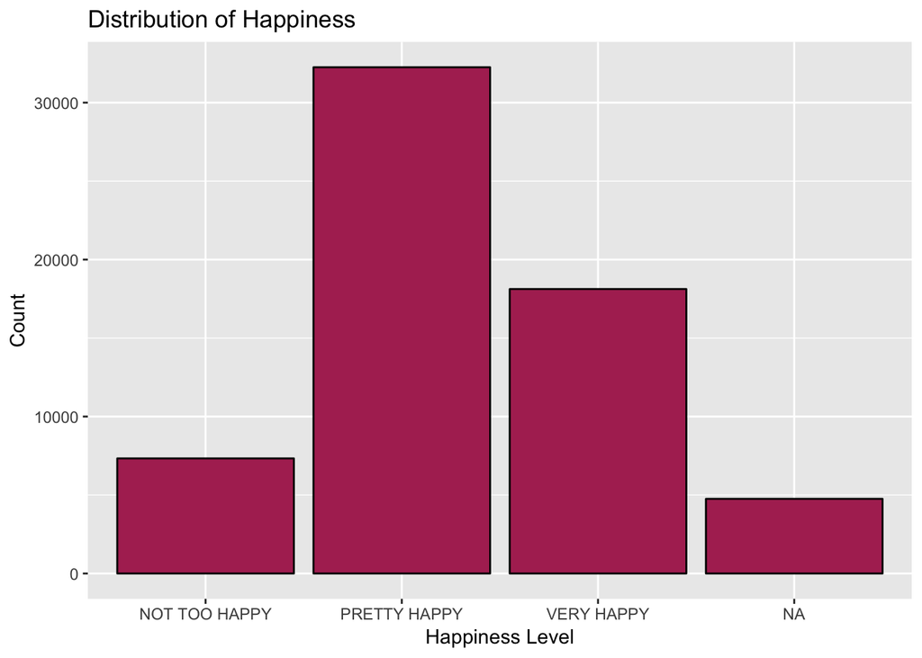

```r
ggplot(happy2, aes(happy)) + geom_bar(color="black", fill="maroon") + xlab("Happiness Level") + ylab("Count") + ggtitle("Distribution of Happiness")
```

We can see from the first histogram, the variable of interest is age. The distribution for age is approximately right skewed as most of the data is to the left of the graph. It is also odd the graph has flucuations throughout the distribution. More exploration will be needed to determine the cause of this. The second graph shows the distribution of happy. It is clear most of the population is “pretty happy”, while the smallest group is “not too happy”. This is important information to know as we continue to explore our data. We will want to see what other variables possibly contribute to people to being “not happy”.

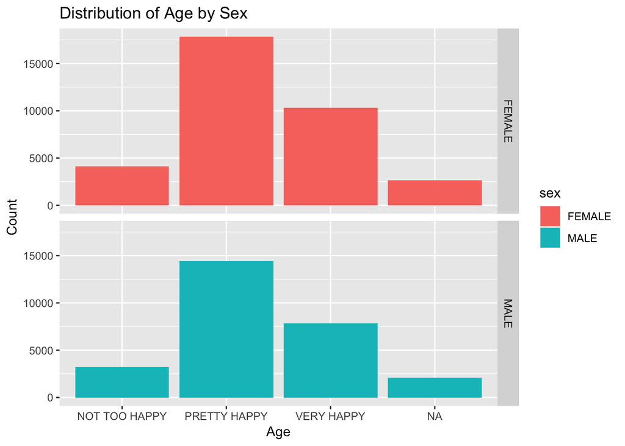

```r
ggplot(happy2, aes(x=happy, fill=sex)) + geom_bar(position="identity", size=0.5) + facet_grid(sex~.) + theme(legend.position = "right") + xlab("Age") + ylab("Count") + ggtitle("Distribution of Age by Sex")
```

From the plot above, we can tell that the distribution of happiness is not really effected by sex as the distributions for happiness for male and female are about the same. This could be useful information in the future when we are trying to build a model for happiness. Since we know happines does not differ between sex, then sex will most likely not bea valuable feature.

The plot below is a boxplot of age grouped by happiness level. We can see from this plot that the median age for “pretty happy” is lower than for “not too happy” and “very happy”. Additionally for “pretty happy”, the third quartile is lower than the other categories as well. This is an indication that age may be a good indication of happiness and should be considered in future modeling.

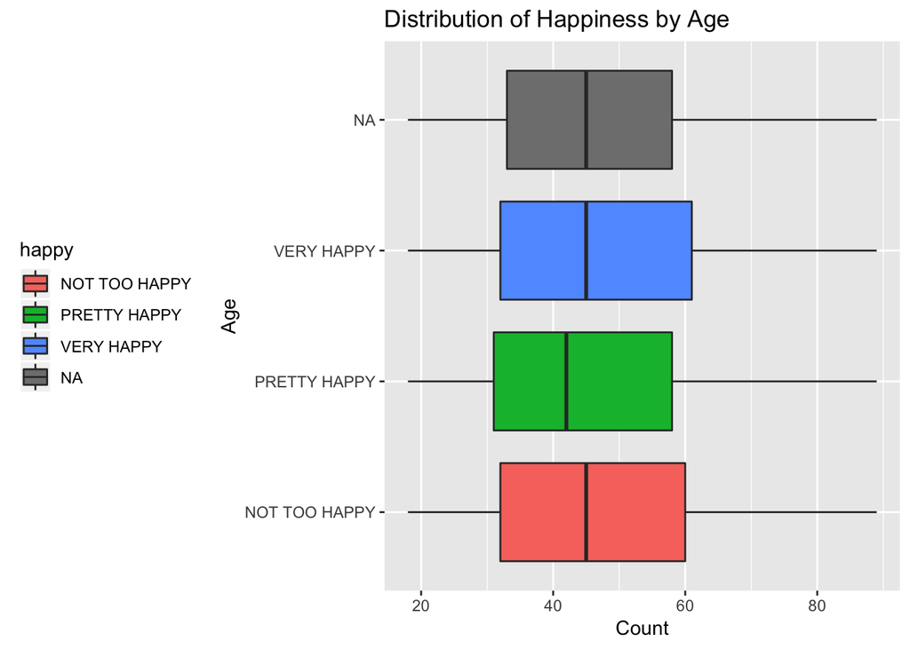

```r
ggplot(happy2, aes(x=happy, y=age, fill=happy)) + geom_boxplot(position="identity", size=0.5) + theme(legend.position = "left") + xlab("Age") + ylab("Count") + ggtitle("Distribution of Happiness by Age") + coord_flip()
```

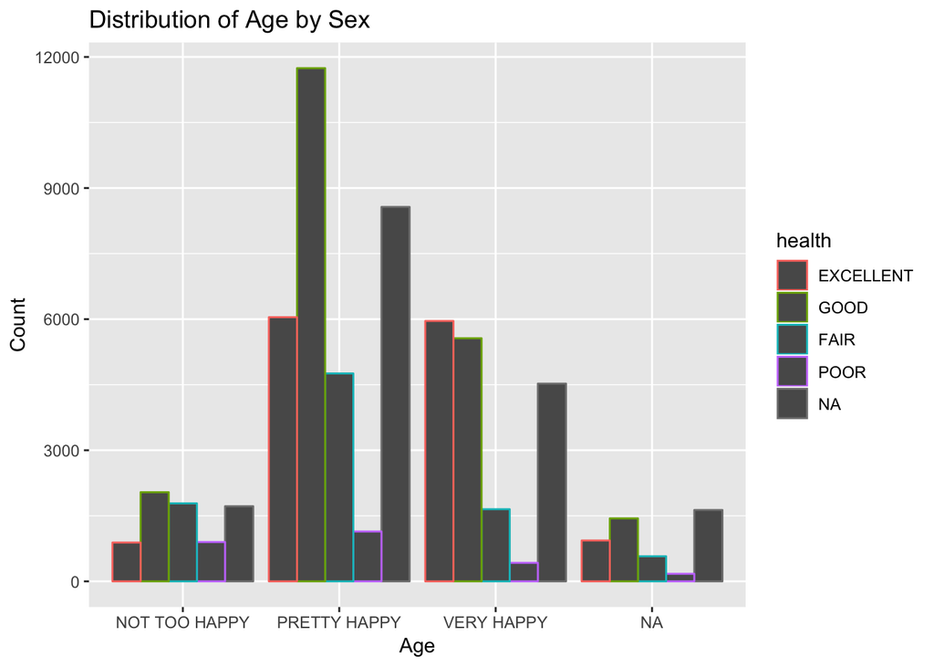

```r
ggplot(happy2, aes(x=happy, color=health)) + geom_bar(position="dodge", size=0.5) + theme(legend.position = "right") + xlab("Age") + ylab("Count") + ggtitle("Distribution of Age by Sex")
```